# DATA607 Project 3 – Data Science Skills

Joe Connolly, Gabriel Campos, Gabriella Martinez, Maliat Islam and Peter Gatica

April 21 2021

### Which are the most valued data science skills?

#### Assignment Requirements

This is a project for your entire class section to work on together, since being able to work effectively on a virtual team is a key *“soft skill”* for data scientists.

Please **note especially** the **requirement** about making a **presentation** during our first meetup after the project is due.

```
    W. Edwards Deming said, “In God we trust, all others must bring data.”
```

**Please use data to answer the question:**

```
    “Which are the most valued data science skills?”
```

Consider your work as an exploration: there is **not** necessarily a *“right answer.”*

##### Grading rubric:

- You will need to determine what **tool(s)** you’ll use as a group to effectively collaborate, **share code** and any **project documentation** *(such as motivation, approach, findings).*
- You will have to determine **what data** to collect, **where the data** can be found, and **how to load** it.
- The data that you decide to collect should reside in a **relational database**, in a set of **normalized tables**.
- You should perform any needed **tidying**, **transformations**, and **exploratory data analysis** in `R`.
- Your deliverable should include all **code**, **results**, and **documentation** of your motivation, approach, and findings.
- As a group, you should appoint $(at\ least)$ *three people* to **lead parts** of the presentation.
- While you are strongly encouraged (and will hopefully find it fun) to try out statistics and data models, your **grade will NOT be affected by the statistical analysis and modeling performed** (since this is a semester one course on Data Acquisition and Management).
- **Every** student must be prepared to **explain how the data** was **collected**, **loaded**, **transformed**, **tidied**, and **analyzed for outliers**, etc. in our *Meetup*.
  - This is the **only way I’ll have to determine that everyone actively participated in the process, so you need to hold yourself responsible for understanding what your class-size team did!*
- If you are **unable to attend the meet up**, then you need to either **present to me one-on-one before the meetup presentation**, or **post a 3 to 5 minute video (e.g. on YouTube) explaining the process**.
  - Individual students will not be responsible for explaining any forays into statistical analysis, modeling, data mining, regression, decision trees, etc.
  - You are encouraged to start early, ask many questions, actively post on the provided discussion forum, etc.

### Database Creation, Import & Export

#### Connect to local Database

Database `job` is created on each team members local machine using MySQL. Using an **Open Data Base Connectivity (ODBC)** Driver. A connection is established using the **Data Source Name (DSN)** linking `R` to the appropriate user with `SELECT` and `INSERT` privileges. All files are made available on a shared githube repository DATA607_CUNY_2021_Project3

```r
  db_conn <- dbConnect(odbc(),"data607")
    dbListTables(db_conn)
```

```
## [1] "job_opening_tbl" "location_dim"
```

```r
# table location_dim fields are listed below
dbListFields(db_conn, "location_dim")
```

```
## [1] "uniq_id"  "location" "city"     "country"  "state"    "zip_code"
```

```r
dbListFields(db_conn, "job_opening_tbl")
```

```
## [1] "uniq_id"   "job_title" "job_descr"
```

#### Load CSV

Function `OD_DL_csv` is created in order to access the necessary `CSV` files containing over 30,000 observations. This method of was select over loading from Github, due to storage limitations with files this large. shared file URL and csv names are stored into variables `url_location`, `url_job_openings`, `csv_location` and `csv_openings` respectively.

`OD_DL_csv` takes the shared file, splits it into a list, uses unlist so further split the elements and them pastes for a downloadable version. from there `curl_download` from the `curl` packages is used to complete the download.

```r
OD_DL_csv <- function(sharedURL, file_name, save2wd = FALSE){

   # Save the shared url
   URL1 <- unlist(strsplit(sharedURL,"[?]"))[1]
   URL1 <- paste0(URL1,"?download=1") # edit URL to make it a downloadable link

   # Download the file to a temp directory using the supplied file name
   curl::curl_download(
      URL1,
      destfile = file.path(tempdir(), file_name),
      mode = "wb"
      )


   # If the user wants it saved to thier working directory this will copy the file
   if(isTRUE(save2wd)){
      file.copy(
         from = paste0(tempdir(),"\\", file_name),
         to = "./")
      }

   # return the CSV as a data.frame
   return(read.csv(paste0(tempdir(), "\\" ,file_name), stringsAsFactors = FALSE))

}
```

Below the variables to be used in retrieve our data is stored.

```r
url_Cleaned_DS <- "https://cuny-my.sharepoint.com/:x:/g/personal/gabriel_campos77_qmail_cuny_edu/EdcuUpO6t1RIqyHw-OP90UQB2qRYY3fcW5RPyA_xT348Qw?e=4HeXbe"

url_DS_job_market<- "https://cuny-my.sharepoint.com/:x:/g/personal/gabriel_campos77_qmail_cuny_edu/Eai1ECgMhthLmrut-eIdD5oBw4715IvolGgyG54owY0nWg?e=D0iRKm"

url_location<-
   "https://cuny-my.sharepoint.com/:x:/g/personal/gabriel_campos77_qmail_cuny_edu/EYAX_5NCc_hFtSUFY0W4NPMBEXiRYtgro4V3vrSJbpTcag?e=aRKrpf"

url_job_openings<-
   "https://cuny-my.sharepoint.com/:x:/g/personal/gabriel_campos77_qmail_cuny_edu/EWni58F8o9BKqLwvF-FDdIEBX7nGv3l7PeueVkrUEPhJ_A?e=9hOyGN"

csv_locations<-
   "job_locations.csv"

csv_job_openings<-
   "job_openings.csv"

csv_DS_job_market <-
  "alldata.csv"

csv_Cleaned_DS<-
  "Cleaned_DS_Jobs.csv"
```

Calling the `OD_DL_csv()` function the csv files are loaded to `location_dim_df` and `job_opening_df`

```r
location_dim_df <- OD_DL_csv(sharedURL = url_location,
          file_name = csv_locations
          )
```

```r
job_opening_df <- OD_DL_csv(sharedURL = url_job_openings,
          file_name = csv_job_openings
          )
```

```r
# additional un tidy data set
DS_job_df <- OD_DL_csv(sharedURL = url_DS_job_market,
          file_name = csv_DS_job_market
          )
```

#### Manipulating Imported CSV Dataset

`filter()` is used to select only the rows associated with the word **Data**.

```r
# to filter 30,000 rows in rmd and lighten the load to MySQL
job_opening_df <- job_opening_df %>%
  filter(grepl('Data',job_title))
```

```r
# to filter 30,000 rows in rmd and lighten the load to MySQL
location_dim_df <- location_dim_df %>%
  filter(uniq_id %in% job_opening_df$uniq_id)
```

`gsub()` along with a specific regex command formats the HTML formatting to a plain text form.

```r
job_opening_df$job_descr <- gsub("<[^>]+>","",job_opening_df$job_descr)
```

```r
# add unique ID column based on row name of each entry
DS_job_df<-cbind( data.frame("uniq_id" = as.integer(rownames(DS_job_df))), DS_job_df)

# add 40K to each uniq_id to ensure none match the first 30K entries of the other sets
DS_job_df<-DS_job_df %>%
  mutate_at( vars("uniq_id") ,
             funs(.+40000))
```

```r
# splitting up the location column to create state, city, zip_code
temp<-as.data.frame(str_split_fixed(DS_job_df$location,",",2))
temp$V2<-str_trim(temp$V2)
temp$V2<-str_replace_all(temp$V2, "\\s", " == ")
DS_job_df<-(temp<-cbind(DS_job_df,"city" = temp$V1,
            as.data.frame(str_split_fixed(temp$V2,"==",2)))%>%
                                              dplyr::rename("state"=V1, "zip_code"=V2))
# loading country column with a constan "United State" value
DS_job_df$country<-"United States"

# quick rearrange
DS_job_df<-DS_job_df %>%
  select(uniq_id,position,description,location,city,state,country,zip_code,company,reviews)
```

```r
job_opening_df <-rbind(DS_job_df %>%
                         select(1,2,3) %>%
                            dplyr::rename( "uniq_id" = `uniq_id`,
                            "job_title" = `position`,
                            "job_descr" = `description`)
                      ,job_opening_df)
```

```r
location_dim_df <-rbind(DS_job_df %>%
                         select(1,4,5,6,7,8),location_dim_df)
```

#### Write to Database

Using [dbWriteTable](https://dbi.r-dbi.org/reference/dbwritetable) function, we are able to write these imported dataframes into the appropriate Database tables on our local Database.

The database consists of 2 tables in 2nd Normal Form as shown below

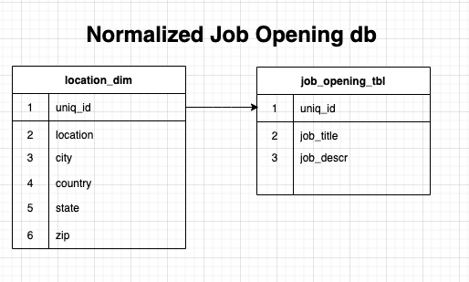

ER Diagram

```r
dbWriteTable(db_conn, name = "location_dim", value = location_dim_df, append = TRUE,row.names = FALSE)
```

```r
dbWriteTable(db_conn, name = "job_opening_tbl", value = job_opening_df, append = TRUE, row.names = FALSE)
```

An [SQL in the Project 3 Repo](https://github.com/gcampos100/DATA607_CUNY_2021_Project3/tree/main/Gabe%20Folder) is used, to retreive the merged data, filtered by job titles, containing the word $DATA$.

```r
db_sql <- read_file(filename)
db_sql <- gsub("\n", " ",db_sql)
str(db_sql)
```

```
##  chr "SELECT j.uniq_id, j.job_title, j.job_descr, l.location FROM jobs.job_opening_tbl j, jobs.location_dim l where j"| __truncated__
```

```r
result_set = dbGetQuery(db_conn, db_sql)
```

```r
class(result_set)
```

```
## [1] "data.frame"
```

### Analysis

#### N-Gram function

```r
phrases <- result_set$job_descr
#view(phrases)

createNgram <-function(stringVector, ngramSize){

  ngram <- data.table()

  ng <- textcnt(stringVector, method = "string", n=ngramSize, tolower = FALSE)

  if(ngramSize==1){
    ngram <- data.table(w1 = names(ng), freq = unclass(ng), length=nchar(names(ng)))
  }
  else {
    ngram <- data.table(w1w2 = names(ng), freq = unclass(ng), length=nchar(names(ng)))
  }
  return(ngram)
}
```

```r
text <- phrases
res <- createNgram(text,1)
names(res)
```

```
## [1] "w1"     "freq"   "length"
```

```r
head(res %>% arrange(desc(freq)),20)%>%
  knitr::kable(caption = "Projection of Word Frequency ")%>%
  kableExtra::kable_styling(bootstrap_options = "striped")
```

Projection of Word Frequency

| w1 | freq | length |
| --- | --- | --- |
| and | 18118 | 3 |
| to | 9548 | 2 |
| of | 7340 | 2 |
| the | 7333 | 3 |
| a | 5924 | 1 |
| in | 5570 | 2 |
| data | 5557 | 4 |
| with | 4827 | 4 |
| for | 3371 | 3 |
| or | 3350 | 2 |
| is | 2302 | 2 |
| our | 1986 | 3 |
| as | 1882 | 2 |
| experience | 1746 | 10 |
| on | 1740 | 2 |
| business | 1646 | 8 |
| will | 1641 | 4 |
| that | 1449 | 4 |
| team | 1448 | 4 |
| are | 1426 | 3 |

Plotting zip codes

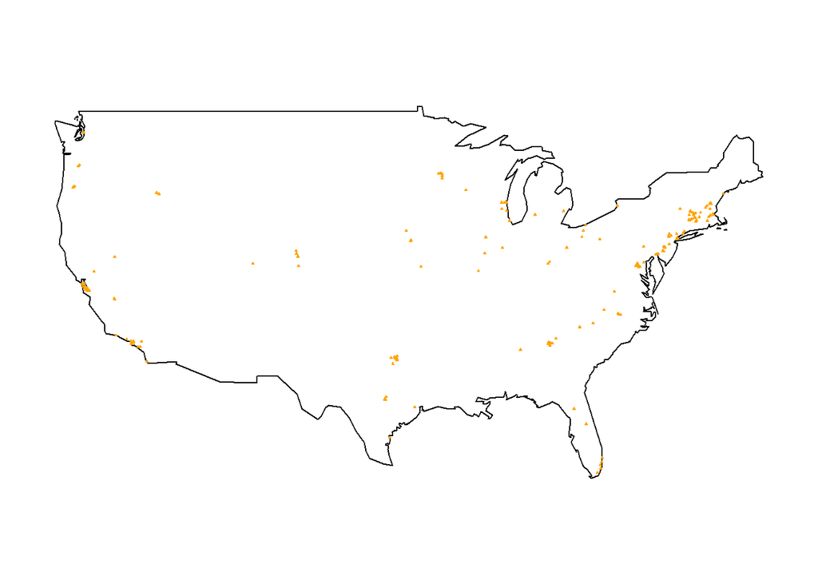

```r
top_states <- location_dim_df$zip_code

zip.plot(location_dim_df, zip.file = system.file("extdata", "zips.tab", package =
"muRL"), map.type = "usa", cex = .2, col = "orange", pch = 2,
jitter.factor = NULL)
```

#### Frequency Count

##### Hard and Tech Skills

Using the N-gram function which can extract single, double or more word combinations, we extracted the most common hard, technical, and soft skills we know from prior experiences and from the articles linked below. Below are the Top 20 Hard and Technical Skills in order of frequency.  
[The Most In-Demand Tech Skills for Data Scientists](https://towardsdatascience.com/the-most-in-demand-tech-skills-for-data-scientists-d716d10c191d)  
[Data Scientist Resume Sample Template & Data-Driven Guide](https://zety.com/blog/data-scientist-resume-example)  
We used the N-gram function twice to extract single word skills, and then once again to extract double worded skills such as "quantitative analysis. In conjunction with the N-gram function, we leveraged dplyr functions to tidy our data, ggplot for the bar graphs and reactable for the table visual of our data.

```r
# hard skills:
#https://towardsdatascience.com/the-most-in-demand-tech-skills-for-data-scientists-d716d10c191d
# technical, hard and soft skills:
#https://zety.com/blog/data-scientist-resume-example
# res1$w1 = tolower(res1s$w1) sets all words to lowercase
job_descr_phrases  <- result_set$job_descr
job_descr_text     <- job_descr_phrases
job_phrases_1      <- createNgram(job_descr_text,1)
job_phrases_1$w1   <- tolower(job_phrases_1$w1) # convert to lowercase for accurate counting
job_phrases_2      <- createNgram(job_descr_text,2)
job_phrases_2$w1w2 <- tolower(job_phrases_2$w1w2)
# hard and tech skills single word skills
techskill = c("python", "R", "r","sql",  "spark",  "hadoop","java",
              "tableau", "aws", "sas", "hive",  "tensorflow", "scala",
              "c++", "excel", "azure", "mathematics", "statistitcs",
              "programming",  "debugging",  "probability", "modeling",
              "matplotlib", "openrefine", "matlab", "bigml", "d3.js",
              "excel","ggplot2","jupyter","nltk","scikit-learn","tensorflow",
              "weka","predictive","ai","mathematics","c", "linux","nosql",
              "basic","bayesian","mapreduce")

hardskill= c("data visualization", "quantitative analysis", "data analysis",
             "artificial intelligence", "predictive analysis", "predictive modeling",
             "bachelors degree", "masters degree")
```

```r
job_phrases_1<-
  job_phrases_1 %>%
    select(-3) %>%
      filter(w1 %in% techskill) %>%
        group_by(w1) %>%
          summarise_all(funs(sum)) %>%
            arrange(desc(freq))

colnames(job_phrases_1)[1] <- "Hard and Tech Skills"
```

```r
#hard and tech double word skills
job_phrases_2<-
  job_phrases_2 %>%
    select(-3) %>%
      filter(w1w2 %in% hardskill) %>%
        group_by(w1w2) %>%
          summarise_all(funs(sum))%>%
            arrange(desc(freq))

colnames(job_phrases_2)[1] <- "Hard and Tech Skills"
```

```r
#combine the single word and two word skills into one dataframe
totaltech <-
  rbind(job_phrases_1, job_phrases_2) %>%
    arrange(desc(freq))

head(totaltech)%>%
  knitr::kable(caption = "Tech Skills for Data Science ")%>%
  kableExtra::kable_styling(bootstrap_options = "striped")
```

Tech Skills for Data Science

| Hard and Tech Skills | freq |
| --- | --- |
| python | 531 |
| sql | 481 |
| modeling | 432 |
| r | 426 |
| programming | 284 |
| spark | 245 |

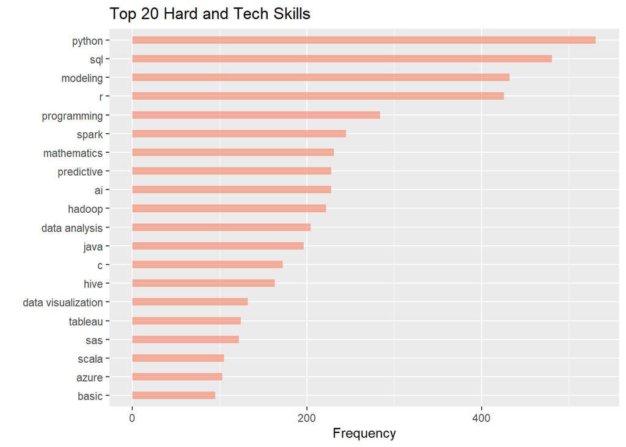

```r
#bar graph top 20 hard and tech skills
totaltech %>%
  top_n(20) %>%
    ggplot(aes(fct_reorder(`Hard and Tech Skills`,`freq`), `freq`))+
      geom_bar(stat="identity", fill="#f68060", alpha=.6, width=.4) +
      coord_flip() +
        xlab("") +
        ylab("Frequency")+
        ggtitle("Top 20 Hard and Tech Skills")
```

```r
reactable(totaltech, bordered = TRUE, striped = TRUE,
          highlight = TRUE, filterable = TRUE,  showPageSizeOptions = TRUE,
          showPagination = TRUE, pageSizeOptions = c(5, 10, 20),
          defaultPageSize = 10)
```

| Hard and Tech Skills | freq |
| --- | --- |
| python | 531 |
| sql | 481 |
| modeling | 432 |
| r | 426 |
| programming | 284 |
| spark | 245 |
| mathematics | 231 |
| ai | 228 |
| predictive | 228 |
| hadoop | 222 |

[output cut: 30 more lines]

##### Soft Skills

Note, for soft skills we extracted words similar to one another such as lead, leadership, and leader and then manually grouped them together since they all are suggestive of the same skill. The soft skills were extracted and orgaized in a similar fashion to the above hard and technical skills.

```r
#soft skills single word
job_phrases_3 <- createNgram(job_descr_text,1)
job_phrases_3$w1 <- tolower(job_phrases_3$w1)
softskill = c("communication", "collaboration","teamwork", "collaborate",
              "professional", "veteran", "lead", "leadership", "leader",
              "innovation", "innovate", "innovative", "collaborative",
              "passionate", "creative", "motivated", "integrity", "effectiveness",
              "pioneering","communication", "collaboration", "preceptiveness",
              "perseptive","teamwork","collaborate")
job_phrases_4 <- createNgram(job_descr_text,2)
job_phrases_4$w1w2 <- tolower(job_phrases_4$w1w2)
softskill2 = c("critical thinking", "problem solving","interpersonal skills",
               "time management")
```

```r
job_phrases_3<-
  job_phrases_3 %>%
    select(-3) %>%
      filter(w1 %in% softskill) %>%
        group_by(w1) %>%
          summarise_all(funs(sum)) %>%
            arrange(desc(freq))

colnames(job_phrases_3)[1] <- "Soft Skills"
```

```r
#soft skills double word
job_phrases_4<- job_phrases_4 %>%
  select(-3) %>%
    filter(w1w2 %in% softskill2) %>%
      group_by(w1w2) %>%
        summarise_all(funs(sum)) %>%
          arrange(desc(freq))
colnames(job_phrases_4)[1] <- "Soft Skills"
```

```r
#combine the single word and two word skills into one dataframe
totalsoft <-
  rbind(job_phrases_3, job_phrases_4) %>%
    arrange(desc(freq)) #arranges in descending order

totalsoft<-
  totalsoft[-c(2,10), ]
totalsoft[7,2] = (302+158+141)

totalsoft<-
  totalsoft[-c(8,15), ]

totalsoft[4,2] = (264+149+53)

totalsoft<-
  totalsoft[-c(12,10), ]
totalsoft[5,2] = (203+106+91)

totalsoft<- arrange(totalsoft,desc(freq))

head(totalsoft)%>%
  knitr::kable(caption = "Soft skills for Data Science jos ")%>%
  kableExtra::kable_styling(bootstrap_options = "striped")
```

Soft skills for Data Science jos

| Soft Skills | freq |
| --- | --- |
| leadership | 601 |
| collaborate | 466 |
| professional | 400 |
| communication | 356 |
| veteran | 265 |
| innovative | 264 |

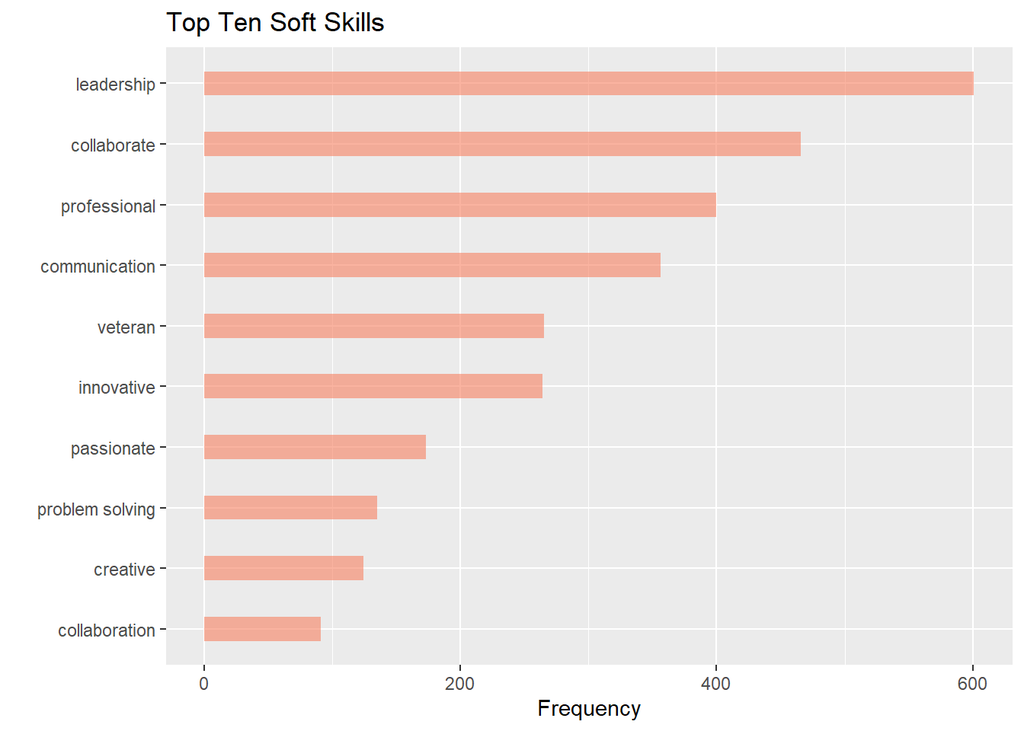

```r
#bar graph top 10 soft skills
totalsoft %>%
  top_n(10) %>%  #extract top 10
    ggplot(aes(fct_reorder(`Soft Skills`,`freq`), `freq`))+
      geom_bar(stat="identity", fill="#f68060", alpha=.6, width=.4) +
      coord_flip() +
      xlab("") +
      ylab("Frequency")+
      ggtitle("Top Ten Soft Skills")
```

```r
reactable(totalsoft, bordered = TRUE, striped = TRUE, highlight = TRUE, filterable = TRUE,  showPageSizeOptions = TRUE, showPagination = TRUE, pageSizeOptions = c(5, 10), defaultPageSize = 5)
```

| Soft Skills | freq |
| --- | --- |
| leadership | 601 |
| collaborate | 466 |
| professional | 400 |
| communication | 356 |
| veteran | 265 |
| innovative | 264 |
| passionate | 173 |
| problem solving | 135 |
| creative | 124 |
| collaboration | 91 |

[output cut: 7 more lines]

#### Percentages

#calc the percentage of hard and tech skills

```r
totaltech_freq_pct <- round((totaltech$freq/nrow(result_set))*100, 2)
(totaltech <- cbind(totaltech, totaltech_freq_pct))%>%
  knitr::kable(caption = "Percentage of Hard and Tech Skills ")%>%
  kableExtra::kable_styling(bootstrap_options = "striped")
```

Percentage of Hard and Tech Skills

| Hard and Tech Skills | freq | totaltech_freq_pct |
| --- | --- | --- |
| python | 531 | 79.49 |
| sql | 481 | 72.01 |
| modeling | 432 | 64.67 |
| r | 426 | 63.77 |
| programming | 284 | 42.51 |
| spark | 245 | 36.68 |
| mathematics | 231 | 34.58 |
| ai | 228 | 34.13 |
| predictive | 228 | 34.13 |
| hadoop | 222 | 33.23 |
| data analysis | 204 | 30.54 |
| java | 196 | 29.34 |
| c | 172 | 25.75 |
| hive | 163 | 24.40 |
| data visualization | 132 | 19.76 |
| tableau | 124 | 18.56 |
| sas | 122 | 18.26 |
| scala | 105 | 15.72 |
| azure | 103 | 15.42 |
| basic | 95 | 14.22 |
| excel | 91 | 13.62 |
| linux | 86 | 12.87 |
| artificial intelligence | 83 | 12.43 |
| aws | 78 | 11.68 |
| predictive modeling | 71 | 10.63 |
| matlab | 70 | 10.48 |
| nosql | 66 | 9.88 |
| tensorflow | 61 | 9.13 |
| mapreduce | 60 | 8.98 |
| quantitative analysis | 29 | 4.34 |
| bayesian | 26 | 3.89 |
| probability | 20 | 2.99 |
| jupyter | 14 | 2.10 |
| masters degree | 12 | 1.80 |
| nltk | 8 | 1.20 |
| bachelors degree | 8 | 1.20 |
| debugging | 7 | 1.05 |
| predictive analysis | 6 | 0.90 |
| matplotlib | 5 | 0.75 |
| weka | 5 | 0.75 |

#bar graph of top 15 hard and tech skills as percentage

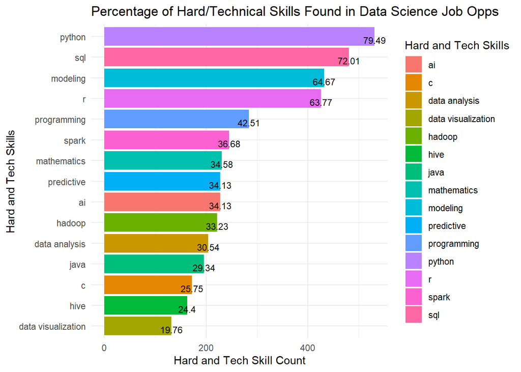

```r
totaltech %>%
  top_n(15) %>%
    ggplot(aes(y=reorder(`Hard and Tech Skills`,freq),x=freq,fill=`Hard and Tech Skills`)) +
      geom_bar(stat = 'identity',position=position_dodge()) +
      geom_text(aes(label=totaltech_freq_pct), vjust=1.0, color="black",
                position = position_dodge(0.9), size=3.0) +
      labs(y = ("Hard and Tech Skills"),x = ("Hard and Tech Skill Count"),
           title = ("Percentage of Hard/Technical Skills Found in Data Science Job Opps")) +
      theme_minimal()
```

```r
totalsoft_freq_pct <- round((totalsoft$freq/nrow(result_set))*100, 2)

(totalsoft <- cbind(totalsoft, totalsoft_freq_pct))%>%
  knitr::kable(caption = "Percentage of Soft Skills ")%>%
  kableExtra::kable_styling(bootstrap_options = "striped")
```

Percentage of Soft Skills

| Soft Skills | freq | totalsoft_freq_pct |
| --- | --- | --- |
| leadership | 601 | 89.97 |
| collaborate | 466 | 69.76 |
| professional | 400 | 59.88 |
| communication | 356 | 53.29 |
| veteran | 265 | 39.67 |
| innovative | 264 | 39.52 |
| passionate | 173 | 25.90 |
| problem solving | 135 | 20.21 |
| creative | 124 | 18.56 |
| collaboration | 91 | 13.62 |
| integrity | 79 | 11.83 |
| pioneering | 52 | 7.78 |
| effectiveness | 37 | 5.54 |
| interpersonal skills | 34 | 5.09 |
| teamwork | 25 | 3.74 |
| critical thinking | 20 | 2.99 |
| time management | 16 | 2.40 |

#bar graph of top 10 soft skills as percentage

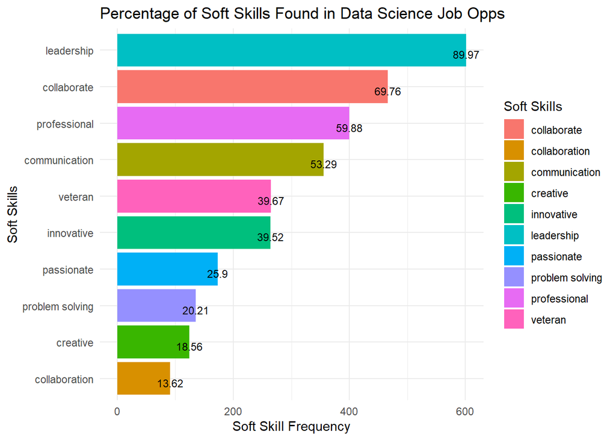

```r
totalsoft %>%
  top_n(10) %>%
    ggplot(aes(y=reorder(`Soft Skills`,freq),x=freq,fill=`Soft Skills`)) +
      geom_bar(stat = 'identity',position=position_dodge()) +
      geom_text(aes(label=totalsoft_freq_pct), vjust=1.0, color="black",
            position = position_dodge(0.9), size=3.0) +
      labs(y = ("Soft Skills"),x = ("Soft Skill Frequency"),
           title = ("Percentage of Soft Skills Found in Data Science Job Opps")) +
      theme_minimal()
```

#### Word cloud and TreeMap

##### Word Cloud

Word cloud reflects that python,sql,and r is a crucial skill for a data scientist to progress in this field. For soft skills leadership,communication and collaboration seems prominent.The Tree Map has identified leadership, collaboration, communication and professional skill as important soft skill to excel as a data scientist.  
**Hard and Tech Skills**

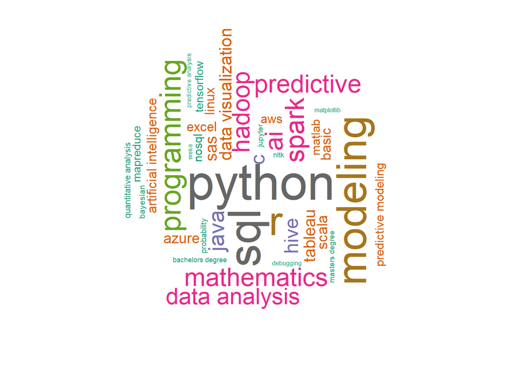

```r
set.seed(1234) # for reproducibility
wordcloud(words =totaltech$`Hard and Tech Skills` ,
          freq = totaltech$freq, min.freq = 1,max.words=200,
          random.order=FALSE,
          rot.per=0.35,
          colors=brewer.pal(8, "Dark2"))
```

**Soft Skills**

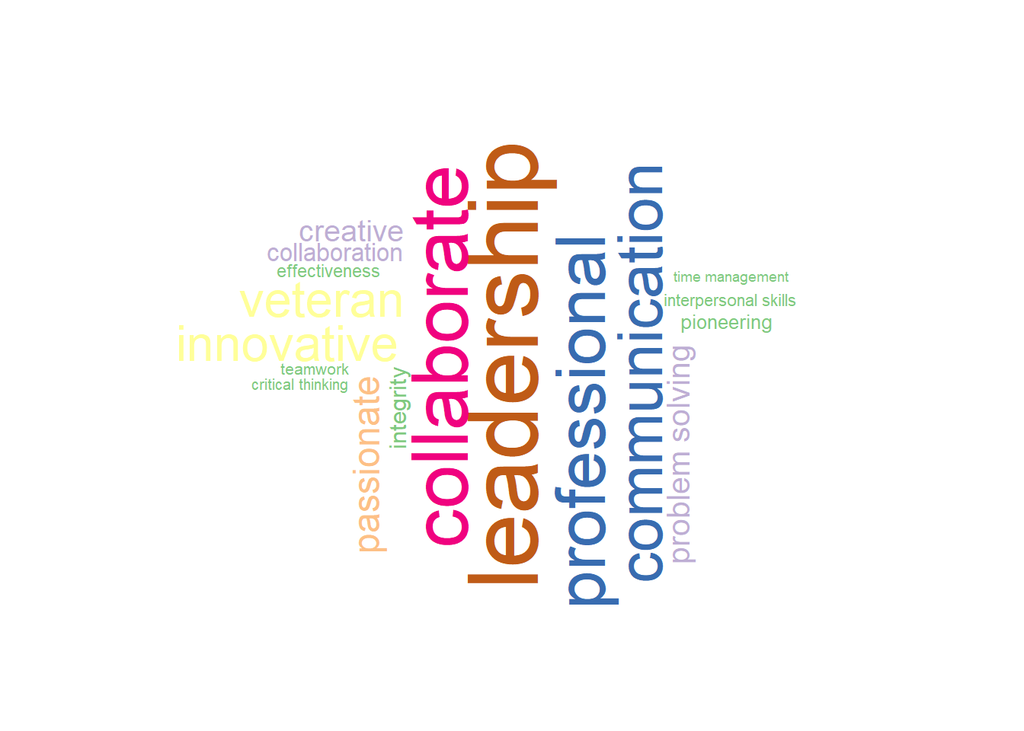

```r
set.seed(1234) # for reproducibility
wordcloud(words =totalsoft$`Soft Skills` ,
          freq = totalsoft$freq, min.freq = 1,max.words=200,
          random.order=FALSE,
          rot.per=0.35,
          colors=brewer.pal(7, "Accent"))
```

##### TreeMap

**Tech Skills**

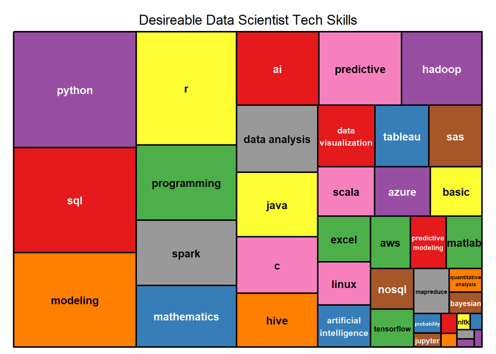

```r
treemap(totaltech,
        index=c("Hard and Tech Skills"),
        vSize = "freq",
        type="index",
        palette ="Set1",
        title="Desireable Data Scientist Tech Skills", #Customize your title
        fontsize.title = 14 #Change the font size of the title
        )
```

**Soft Skills**

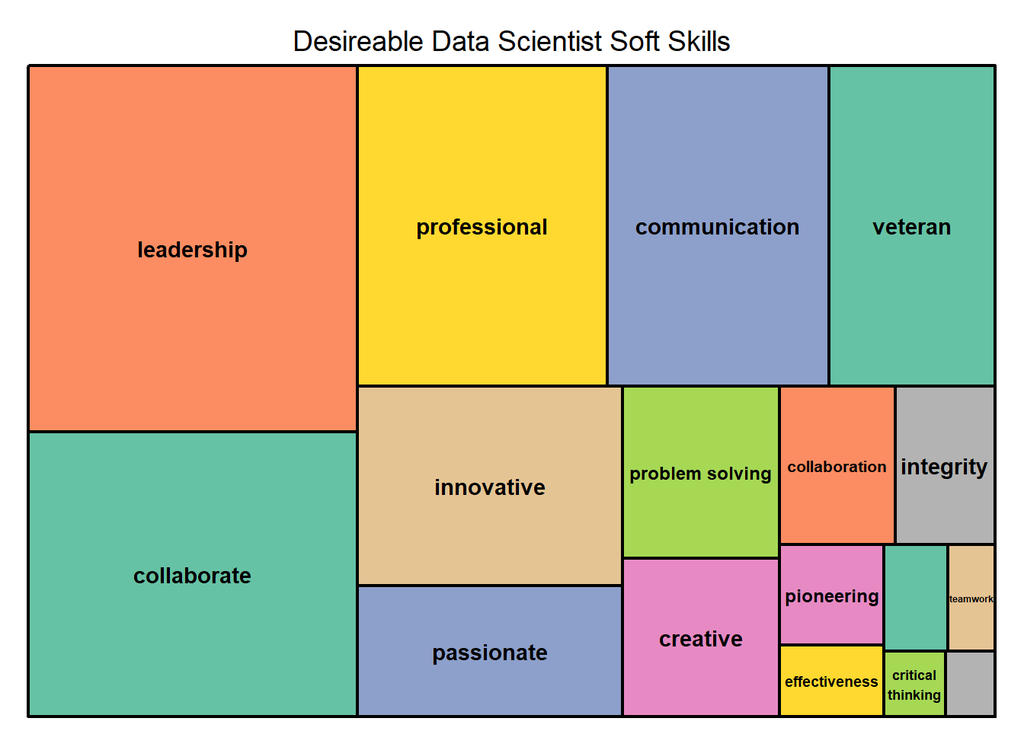

```r
treemap(totalsoft, #
        index=c("Soft Skills"),
        vSize = "freq",
        type="index",
        palette ="Set2",
        title="Desireable Data Scientist Soft Skills",
        fontsize.title = 14
        )
```

### Conclusion

This project was a pleasure to do as we all learned from each other and expanded our skill sets simultaneously. We now understand as witnesses that soft skills are just as important as the hard skills. This is because the soft skills allowed us to get the work done in an effective manner, which is the most important goal for any project.